Румянцева Елизавета Ивановна КВБО-01-21

# 1.3 Задание

Выведите на печать и определите тип переменной

```python
x=5>=2
A={1,3,7,8}
B={2,4,5,10,'apple'}
C=A&B
df='Антоновна Антонина',34,'ж'
z='type'
D=[1,'little',2,'content']
print(x,' ',type(x),'\n',A,' ',type(A),'\n',B,' ',type(B),'\n',C,' ',type(C),'\n',df,' ',type(df),'\n',z,' ',type(z),'\n',D,' ',type(D))
```

```
True   <class 'bool'>
 {8, 1, 3, 7}   <class 'set'>
 {2, 4, 5, 'apple', 10}   <class 'set'>
 set()   <class 'set'>
 ('Антоновна Антонина', 34, 'ж')   <class 'tuple'>
 type   <class 'str'>
 [1, 'little', 2, 'content']   <class 'list'>
```

# 2.3 Задание

Напишите код. Задается x,напечатать какому из интервалов принадлежит (-infinity,-5),[-5,5] или от (5,+infinity)

```python
x=int(input())
if(x<-5):
    print("Перемнная принадлежит к интервалу (-infinity,-5)")

elif((x>=-5)and(x<=5)):
    print("Перемнная принадлежит к интервалу [-5,5]")

elif(x>5):
    print("Перемнная принадлежит к интервалу (5,+infinity)")
```

```
9358
Перемнная принадлежит к интервалу (5,+infinity)
```

# 3.3.1 Задание

Выведете числа от 10 до 1 с шагом 3.

```python
x=10
while x>=1:
    print(x)
    x=x-3
```

```
10
7
4
1
```

# 3.3.2 Задание

При решении задач машинного обучения часто в качестве объектов исследования выступает человек. Создайте список значимых характеристик (признаков), индетифицирующих человека. Выведете список на экран.

```python
human=['2 руки','2 ноги','голубые глаза','русые волосы']
for human in human:
    print(human)
```

```
2 руки
2 ноги
голубые глаза
русые волосы
```

# 3.3.3 Задание

Создать список чисел от 2 до 15 с шагом 1

```python
list_int=range(2,16,1)
print(list(list_int))
```

```
[2, 3, 4, 5, 6, 7, 8, 9, 10, 11, 12, 13, 14, 15]
```

# 3.3.4 Задание

Выведите числа из задания 3.3.3 на for с функцией range() в обратном порядке

```python
list_int=range(15,0,-1)
print(list(list_int))
```

```
[15, 14, 13, 12, 11, 10, 9, 8, 7, 6, 5, 4, 3, 2, 1]
```

# 3.3.5 Задание

Срез. Напишите код, который все элементы массива x с четными индексами переставит в обратном порядке.То есть если x=[0,1,2,3,4,5,6,7,8,9], то код должен сформировать [8,1,6,3,4,5,2,7,0,9]

```python
list_int=[0,1,2,3,4,5,6,7,8,9]
print(list(list_int))
list_int[0::2]=reversed(list_int[0::2])
print(list_int)
```

```
[0, 1, 2, 3, 4, 5, 6, 7, 8, 9]
[8, 1, 6, 3, 4, 5, 2, 7, 0, 9]
```

# 4.3.1 Задание

Задайте массив случайных значений из интервала(0;1). Расчитайте средние и медианные значения для массива, сравните результаты, какие выводы можно сделать о значениях? Постройте точечную диаграмму рассения полученного ряда.

```
Массив:
0.37
0.91
0.88
0.15
0.84
0.17
0.61
0.39
0.6
0.4
```

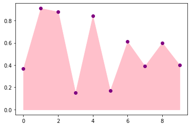

```
0.53  -среднее значение массива
Отсортированные массив:
0.15
0.17
0.37
0.39
0.4
0.6
0.61
0.84
0.88
0.91
0.5  -медианное значение массива

Вывод: значение медианное и среднее арифметическое массива близкие по значению, но не обязательно равны
```

```python
import random
import math
import matplotlib.pyplot as plt
import numpy as np
m = 10
mass=[]
massx=[]
sum=0.0;
print("Массив: ")
for i in range(m):
   mass.append(round(random.random(),2))
   print(mass[i])
for i in range(m):
    massx.append(i)
x=np.array(massx)
y=np.array(mass)
plt.fill_between(x, y, np.zeros_like(y), color='pink')
plt.scatter(x,y,c='purple')
plt.show()
for i in range(m):
    sum=sum+mass[i]
srdnz=sum/len(mass)
print(round(srdnz,2)," -среднее значение массива")
mass.sort()
print("Отсортированные массив: ")
for i in range(m):
   print(mass[i])
if(m%2==0):
    mediana=(mass[math.floor(m/2)]+mass[math.floor(m/2)-1])/2
elif(m%2!=0):
    mediana=mass[math.floor(m/2)]
print(mediana," -медианное значение массива")
print("\nВывод: значение медианное и среднее арифметическое массива близкие по значению, но не обязательно равны")
```

Медиана выборки числовых данных - это значение, которое находится посередине при сортировке данных. Данные могут быть отсортированы по возрастанию или убыванию, медиана остается прежней.

Чтобы найти медиану, нам необходимо:

1)Отсортировать образец 2)Найдите значение в середине отсортированного образца

# 4.3.2 Дана функция. Моздать массив из 10 значений функции(x, например, изменяется от 1 до 10).Выделить срез первой половины массива и построить графики для основного массива-линейный и для среза-точечный

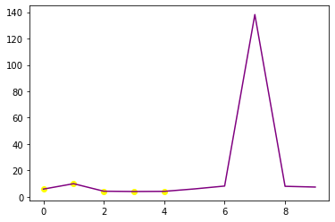

```python
import matplotlib.pyplot as plt
import numpy as np
import math
m=10
massx=[]
massy=[]
massy1=[]
massx1=[]
for i in range(m):
    massx.append(i)
x=np.array(massx)
for i in range(m):
    slagaemoe=math.log(math.fabs(2*(i+1)))
    chislitel=math.sqrt(1+math.pow(math.e,math.sqrt(i+1))+math.cos((i+1)*((i+1))))
    znamenatel=math.fabs(1-math.sin(i+1)*math.sin(i+1)*math.sin(i+1))
    massy.append(slagaemoe+(chislitel/znamenatel))
y=np.array(massy)
plt.plot(x,y,c='purple')
j=math.floor((m+1)/2)
for i in range(j):
    massy1.append(massy[i])
    massx1.append(massx[i])
x1=np.array(massx1)
y1=np.array(massy1)
plt.scatter(x1,y1,c='yellow')
plt.show()
```

# 4.3.3 Задание

Дана функция. Построить график на интревале (0,10) с шагом 1 с заливкой площади и найти эту площадь под ним. Для вычисления площади воспользуйтесь функции trapz(),вычисляющей интеграл по правилу трапеции.

```
4.94775375687229
```

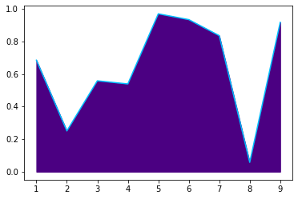

```python
from scipy.integrate import simps
from numpy import trapz
import matplotlib.pyplot as plt
import numpy as np
import math
m=10
massx=[]
massy=[]
for i in range(1,m):
    massx.append(i)
x=np.array(massx)
for i in range(1,m):
    massy.append(math.fabs(math.cos((i+1)*pow(math.e,(math.cos((i+1))+math.log((i+1)+1))))))
y=np.array(massy)
plt.plot(x,y,c='deepskyblue')
plt.fill_between(x, y, np.zeros_like(y), color='indigo')
print(np.trapz(massy))
```

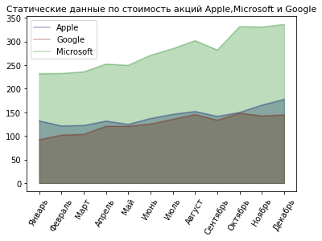

```python
import matplotlib.pyplot as plt
import numpy as np
import math
m=12
massx=["Январь","Февраль","Март","Апрель","Май","Июнь","Июль","Август","Сентябрь","Октябрь","Ноябрь","Декабрь"]
massyApple=[131.96,121.26,122.15,131.46,124.61,136.96,145.86,151.83,141.5,149.8,165.3,177.57]
massyGoogle=[91.79,101.84,103.43,120.51,120.58,125.32,135.22,145.46,133.27,148.27,142.45,144.68]
massyMicrosoft=[231.96,232.38,235.77,252.18,249.68,270.9,284.91,301.88,281.92,331.62,330.59,336.32]
x=np.array(massx)
yA=np.array(massyApple)
yG=np.array(massyGoogle)
yM=np.array(massyMicrosoft)
plt.title('Статические данные по стоимость акций Аpple,Microsoft и Google', fontsize=11)
plt.plot(x, yA, color='navy', alpha=0.3,label='Apple')
plt.fill_between(x, yA, color='navy', alpha=0.3)
plt.plot(x, yG, color='darkred', alpha=0.3,label='Google')
plt.fill_between(x, yG, color='darkred', alpha=0.3)
plt.plot(x, yM, color='forestgreen', alpha=0.3,label='Microsoft')
plt.fill_between(x, yM, color='forestgreen', alpha=0.3)
plt.legend()
plt.xticks(rotation=60)
plt.show()
```

# 4.3.5 Задание

```python
f = 'Введите первое число:  '
o = 'Введите операцию (+,-, /, *):  '
s = 'Введите второе число:  '
r = 'Результат: '
e = 'Ошибка'
v = 'Введите "yes", чтобы продолжить, и любую клавишу, чтобы закончить:  '
prodolzhit = 'yes'
while prodolzhit == 'yes':
    f_num = float(input(f))
    oper = input(o)
    sec_num = float(input(s))
    if oper == '+':
        print(r, f_num + sec_num)
    elif oper == '-':
        print(r, f_num - sec_num)
    elif oper == '/':
        print(r, f_num / sec_num)
    elif oper == '*':
        print(r, f_num * sec_num)
    else:
        print(e)
    prodolzhit = input(v)
```

```
Введите первое число:  4
Введите операцию (+,-, /, *):  /
Введите второе число:  5
Результат:  0.8
Введите "yes", чтобы продолжить, и любую клавишу, чтобы закончить:  yes
Введите первое число:  1947
Введите операцию (+,-, /, *):  *
Введите второе число:  6
Результат:  11682.0
Введите "yes", чтобы продолжить, и любую клавишу, чтобы закончить:
```